# DM Logiciel R4

## Question 1

```r
data<-read.csv("Salaire.csv",header=TRUE,sep=",")
head(data)
```

```
##   education sud nonblanc femme marie experience syndicat lsalaire age annee
## 1        12   0        0     0     0          8        0   1.2150  25    78
## 2        12   0        0     1     1         30        1   1.6094  47    78
## 3         6   0        0     0     1         38        1   2.1401  49    78
## 4        12   0        0     0     1         19        1   2.0732  36    78
## 5        12   0        0     0     1         11        0   1.6490  28    78
## 6         8   0        0     0     1         43        0   1.7148  56    78
```

```r
colnames(data)
```

```
##  [1] "education"  "sud"        "nonblanc"   "femme"      "marie"
##  [6] "experience" "syndicat"   "lsalaire"   "age"        "annee"
```

```r
attach(data)
```

Toutes les variables sont biens présentes.

## Question 2

```r
str(data)
```

```
## 'data.frame':    1084 obs. of  10 variables:
##  $ education : int  12 12 6 12 12 8 11 15 16 15 ...
##  $ sud       : int  0 0 0 0 0 0 0 0 0 0 ...
##  $ nonblanc  : int  0 0 0 0 0 0 0 0 0 0 ...
##  $ femme     : int  0 1 0 0 0 0 0 1 1 0 ...
##  $ marie     : int  0 1 1 1 1 1 0 0 0 1 ...
##  $ experience: int  8 30 38 19 11 43 2 9 17 23 ...
##  $ syndicat  : int  0 1 1 1 0 0 0 0 0 1 ...
##  $ lsalaire  : num  1.22 1.61 2.14 2.07 1.65 ...
##  $ age       : int  25 47 49 36 28 56 18 29 38 43 ...
##  $ annee     : int  78 78 78 78 78 78 78 78 78 78 ...
```

```r
data$sud=as.factor(data$sud)
data$nonblanc=as.factor(data$nonblanc)
data$femme=as.factor(data$femme)
data$marie=as.factor(data$marie)
data$syndicat=as.factor(data$syndicat)
data$annee=as.factor(data$annee)
str(data)
```

```
## 'data.frame':    1084 obs. of  10 variables:
##  $ education : int  12 12 6 12 12 8 11 15 16 15 ...
##  $ sud       : Factor w/ 2 levels "0","1": 1 1 1 1 1 1 1 1 1 1 ...
##  $ nonblanc  : Factor w/ 2 levels "0","1": 1 1 1 1 1 1 1 1 1 1 ...
##  $ femme     : Factor w/ 2 levels "0","1": 1 2 1 1 1 1 1 2 2 1 ...
##  $ marie     : Factor w/ 2 levels "0","1": 1 2 2 2 2 2 1 1 1 2 ...
##  $ experience: int  8 30 38 19 11 43 2 9 17 23 ...
##  $ syndicat  : Factor w/ 2 levels "0","1": 1 2 2 2 1 1 1 1 1 2 ...
##  $ lsalaire  : num  1.22 1.61 2.14 2.07 1.65 ...
##  $ age       : int  25 47 49 36 28 56 18 29 38 43 ...
##  $ annee     : Factor w/ 2 levels "78","85": 1 1 1 1 1 1 1 1 1 1 ...
```

On transforme les variables dummies en facteur.

## Question 3

```r
dataquant<-data[,-c(2,3,4,5,7,10,11)]
mon_summary<-t(data.frame(min=apply(dataquant,2,min),Q25=apply(dataquant,2,quantile,.25),Mediane=apply(dataquant,2,median),Moy=apply(dataquant,2,mean),Q75=apply(dataquant,2,quantile,.75),max=apply(dataquant,2,max),ecart_type=apply(dataquant,2,sd)))
mon_summary%>%kable(caption="Sommaire des variables quantitatives")
```

Sommaire des variables quantitatives

|  | education | experience | lsalaire | age |
| --- | --- | --- | --- | --- |
| min | 1.000000 | 0.00000 | -0.4700000 | 18.00000 |
| Q25 | 12.000000 | 8.00000 | 1.4702000 | 27.00000 |
| Mediane | 12.000000 | 15.00000 | 1.8326000 | 34.00000 |
| Moy | 12.773985 | 18.27675 | 1.8673007 | 36.53967 |
| Q75 | 14.000000 | 28.00000 | 2.2251000 | 46.00000 |
| max | 18.000000 | 55.00000 | 3.7955000 | 64.00000 |
| ecart_type | 2.705561 | 12.88119 | 0.5428042 | 12.20392 |

```r
mon_summary2<-t(data.frame(min=apply(dataquant[data$annee=="78",],2,min),Q25=apply(dataquant[data$annee=="78",],2,quantile,.25),Mediane=apply(dataquant[data$annee=="78",],2,median),Moy=apply(dataquant[data$annee=="78",],2,mean),Q75=apply(dataquant[data$annee=="78",],2,quantile,.75),max=apply(dataquant[data$annee=="78",],2,max),ecart_type=apply(dataquant[data$annee=="78",],2,sd)))
mon_summary2%>%kable(caption="Sommaire des variables quantitatives pour l'année 1978")
```

Sommaire des variables quantitatives pour l’année 1978

|  | education | experience | lsalaire | age |
| --- | --- | --- | --- | --- |
| min | 1.000000 | 1.00000 | -0.470000 | 18.00000 |
| Q25 | 12.000000 | 7.00000 | 1.321800 | 26.00000 |
| Mediane | 12.000000 | 15.00000 | 1.658200 | 33.00000 |
| Moy | 12.536364 | 18.71818 | 1.681002 | 36.25455 |
| Q75 | 14.000000 | 30.00000 | 2.014900 | 47.00000 |
| max | 18.000000 | 55.00000 | 3.351400 | 64.00000 |
| ecart_type | 2.772087 | 13.34653 | 0.490157 | 12.65432 |

```r
mon_summary3<-t(data.frame(min=apply(dataquant[data$annee=="85",],2,min),Q25=apply(dataquant[data$annee=="85",],2,quantile,.25),Mediane=apply(dataquant[data$annee=="85",],2,median),Moy=apply(dataquant[data$annee=="85",],2,mean),Q75=apply(dataquant[data$annee=="85",],2,quantile,.75),max=apply(dataquant[data$annee=="85",],2,max),ecart_type=apply(dataquant[data$annee=="85",],2,sd)))
mon_summary3%>%kable(caption="Sommaire des variables quantitatives pour l'année 1985")
```

Sommaire des variables quantitatives pour l’année 1985

|  | education | experience | lsalaire | age |
| --- | --- | --- | --- | --- |
| min | 2.000000 | 0.00000 | 0.0000000 | 18.00000 |
| Q25 | 12.000000 | 8.00000 | 1.6582000 | 28.00000 |
| Mediane | 12.000000 | 15.00000 | 2.0513000 | 35.00000 |
| Moy | 13.018727 | 17.82210 | 2.0591815 | 36.83333 |
| Q75 | 15.000000 | 26.00000 | 2.4204000 | 44.00000 |
| max | 18.000000 | 55.00000 | 3.7955000 | 64.00000 |
| ecart_type | 2.615373 | 12.37971 | 0.5277335 | 11.72657 |

## Question 4

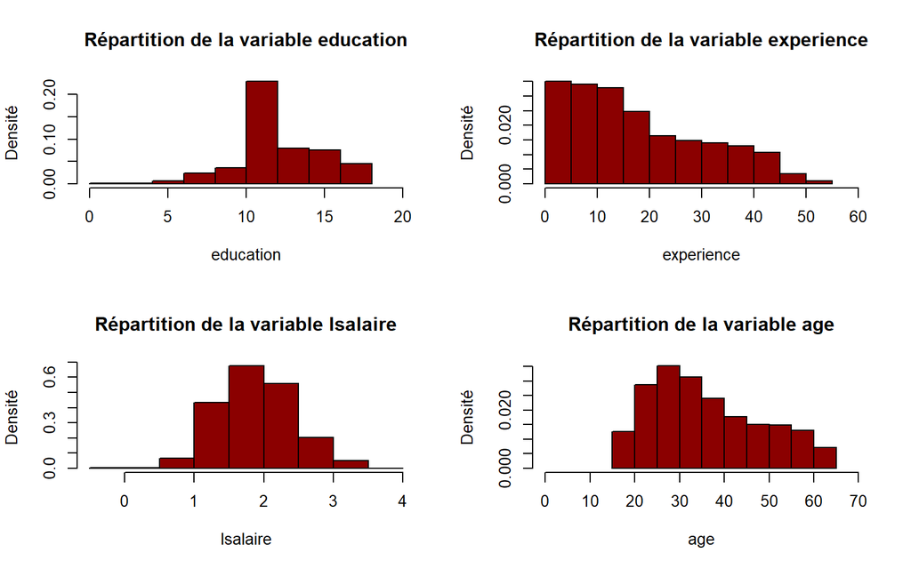

```r
par(mfrow=c(2,2))
hist(education,prob=T,col="darkred",main="Répartition de la variable education",ylab="Densité",xlim=c(0,20))
hist(experience,prob=T,col="darkred",main="Répartition de la variable experience",ylab="Densité",xlim=c(0,60))
hist(lsalaire,prob=T,col="darkred",main="Répartition de la variable lsalaire",ylab="Densité")
hist(age,prob=T,col="darkred",main="Répartition de la variable age",ylab="Densité",xlim=c(0,70))
```

Ici il est plus intéressant d’utiliser le logarithme du salaire car il y a un problème d’échelle entre cette variable et les autres. Le salaire est souvent donnée en milliers d’euros, en utilisant le log on corrige cela, en quelque sorte on “lisse” les données.

## Question 5

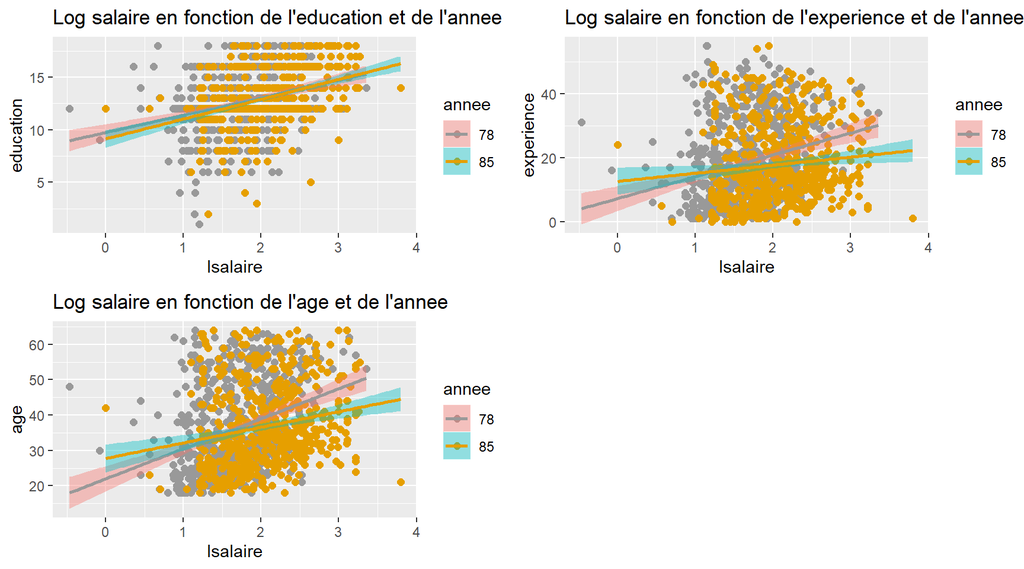

```r
g<-ggplot(data, aes(x=data$lsalaire,y=data$education,fill=annee,color=annee))+
  geom_point(size=2)+
  labs(title="Log salaire en fonction de l'education et de l'annee",x="lsalaire",y="education")+
  scale_color_manual(values=c("#999999", "#E69F00", "#56B4E9"))+
  geom_smooth(method="lm")

h<-ggplot(data, aes(x=data$lsalaire,y=data$experience,color=annee,fill=annee))+
  geom_point(size=2)+
  labs(title="Log salaire en fonction de l'experience et de l'annee",x="lsalaire",y="experience")+
  scale_color_manual(values=c("#999999", "#E69F00", "#56B4E9"))+
  geom_smooth(method="lm")

i<-ggplot(data, aes(x=data$lsalaire,y=data$age,color=annee,fill=annee))+
  geom_point(size=2)+
  labs(title="Log salaire en fonction de l'age et de l'annee",x="lsalaire",y="age")+
  scale_color_manual(values=c("#999999", "#E69F00", "#56B4E9"))+
  geom_smooth(method="lm")

grid.arrange(g,h,i,nrow=2,ncol=2)
```

Ici, on se rend compte que le salaire augmente pour toute les variables avec les années, on s’attend donc à une relation positive entre le salaire et l’annee et une relation positive entre les variables quantitatives et l’année. En ce qui concerne la relation entre la variable à expliquer et les variables quantitatives, elle semble être positive.

## Question 6

```r
data2<-data[data$annee=="78",]
data3<-data[data$annee=="85",]
#Pourcentage de personnes n'habitant pas dans le sud en 1978
(sum(data2$sud=="0")/550)*100
```

```
## [1] 70.36364
```

```r
#Pourcentage de personnes habitant dans le sud en 1978
(sum(data2$sud=="1")/550)*100
```

```
## [1] 29.63636
```

```r
#Pourcentage de personnes n'habitant pas dans le sud en 1985
(sum(data3$sud=="0")/534)*100
```

```
## [1] 70.78652
```

```r
#Pourcentage de personnes habitant dans le sud en 1985
(sum(data3$sud=="1")/534)*100
```

```
## [1] 29.21348
```

```r
#Pourcentage de personnes blanches en 1978
(sum(data2$nonblanc=="0")/550)*100
```

```
## [1] 89.63636
```

```r
#Pourcentage de personnes de couleurs en 1978
(sum(data2$nonblanc=="1")/550)*100
```

```
## [1] 10.36364
```

```r
#Pourcentage de personnes blanches en 1985
(sum(data3$nonblanc=="0")/534)*100
```

```
## [1] 87.45318
```

```r
#Pourcentage de personnes de couleurs en 1985
(sum(data3$nonblanc=="1")/534)*100
```

```
## [1] 12.54682
```

```r
#Pourcentage d'hommes en 1978
(sum(data2$femme=="0")/550)*100
```

```
## [1] 62.36364
```

```r
#Pourcentage de femmes en 1978
(sum(data2$femme=="1")/550)*100
```

```
## [1] 37.63636
```

```r
#Pourcentage d'hommes en 1985
(sum(data3$femme=="0")/534)*100
```

```
## [1] 54.11985
```

```r
#Pourcentage de femmes en 1985
(sum(data3$femme=="1")/534)*100
```

```
## [1] 45.88015
```

```r
#Pourcentage de non syndicat 1978
(sum(data2$syndicat=="0")/550)*100
```

```
## [1] 69.45455
```

```r
#Pourcentage de syndicat 1978
(sum(data2$syndicat=="1")/550)*100
```

```
## [1] 30.54545
```

```r
#Pourcentage de non syndicat en 1985
(sum(data3$syndicat=="0")/534)*100
```

```
## [1] 82.02247
```

```r
#Pourcentage de syndicat en 1985
(sum(data3$syndicat=="1")/534)*100
```

```
## [1] 17.97753
```

```r
#Pourcentage de personne non marié 1978
(sum(data2$marie=="0")/550)*100
```

```
## [1] 34.72727
```

```r
#Pourcentage de personne  marié 1978
(sum(data2$marie=="1")/550)*100
```

```
## [1] 65.27273
```

```r
#Pourcentage de personne non marié en 1985
(sum(data3$marie=="0")/534)*100
```

```
## [1] 34.45693
```

```r
#Pourcentage de personne marié en 1985
(sum(data3$marie=="1")/534)*100
```

```
## [1] 65.54307
```

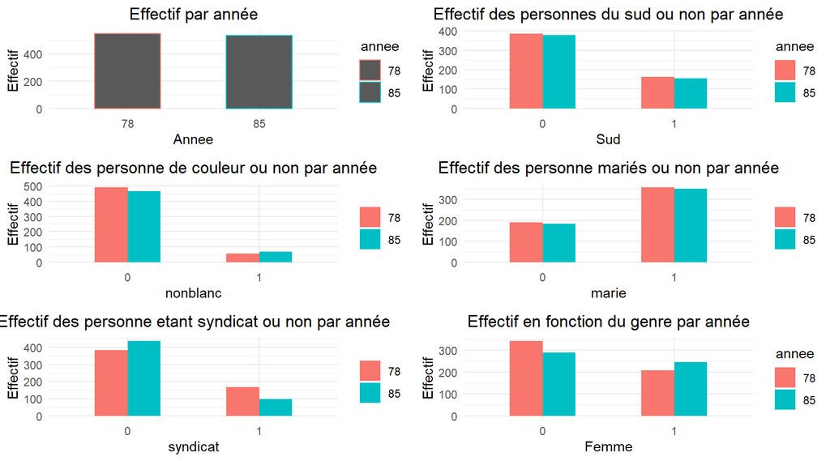

```r
o<-ggplot(data) + aes(x=annee,color=annee) +
  geom_bar(width = 0.5, position = "dodge")+
  labs(x = "Annee", y = "Effectif") +
  ggtitle("Effectif par année") +
  theme_minimal() +
  theme(plot.title = element_text(hjust = 0.5),
        legend.title = element_blank()+
          geom_text(aes( label = scales::percent(..prop..),
                         y= ..prop.. ), stat= "count") )

j<-ggplot(data) + aes(x=sud, fill=annee) +
  geom_bar(width = 0.5, position = "dodge")+
  labs(x = "Sud", y = "Effectif") +
  ggtitle("Effectif des personnes du sud ou non par année") +
  theme_minimal() +
  theme(plot.title = element_text(hjust = 0.5),
        legend.title = element_blank()+
          geom_text(aes( label = scales::percent(..prop..),
                         y= ..prop.. ), stat= "count") )
#non blanc

k<-ggplot(data) + aes(x=nonblanc, fill=annee) +
  geom_bar(width = 0.5, position = "dodge")+
  labs(x = "nonblanc", y = "Effectif") +
  ggtitle("Effectif des personne de couleur ou non par année") +
  theme_minimal() +
  theme(plot.title = element_text(hjust = 0.5),
        legend.title = element_blank())


#Marie

l<-ggplot(data) + aes(x=marie, fill=annee) +
  geom_bar(width = 0.5, position = "dodge")+
  labs(x = "marie", y = "Effectif") +
  ggtitle("Effectif des personne mariés ou non par année") +
  theme_minimal() +
  theme(plot.title = element_text(hjust = 0.5),
        legend.title = element_blank())


#Syndicat

m<-ggplot(data) + aes(x=syndicat, fill=annee) +
  geom_bar(width = 0.5, position = "dodge")+
  labs(x = "syndicat", y = "Effectif") +
  ggtitle("Effectif des personne etant syndicat ou non par année") +
  theme_minimal() +
  theme(plot.title = element_text(hjust = 0.5),
        legend.title = element_blank())

n<-ggplot(data) + aes(x=femme, fill=annee) +
  geom_bar(width = 0.5, position = "dodge")+
  labs(x = "Femme", y = "Effectif") +
  ggtitle("Effectif en fonction du genre par année") +
  theme_minimal() +
  theme(plot.title = element_text(hjust = 0.5),
        legend.title = element_blank()+
          geom_text(aes( label = scales::percent(..prop..),
                         y= ..prop.. ), stat= "count") )


grid.arrange(o,j,k,l,m,n,nrow=3,ncol=2)
```

## Question 7

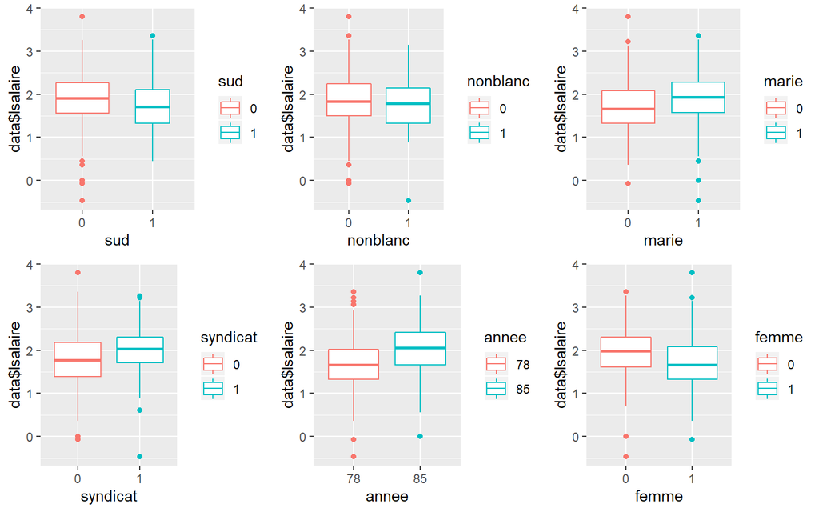

```r
a<-ggplot(data, aes(x=sud,y=data$lsalaire,color=sud))+
  geom_boxplot(varwidth =T)

b<-ggplot(data, aes(x=nonblanc,y=data$lsalaire,color=nonblanc))+
  geom_boxplot()

c<-ggplot(data, aes(x=marie,y=data$lsalaire,color=marie))+
  geom_boxplot()

d<-ggplot(data, aes(x=syndicat,y=data$lsalaire,color=syndicat))+
  geom_boxplot()

e<-ggplot(data, aes(x=annee,y=data$lsalaire,color=annee))+
  geom_boxplot()

f<-ggplot(data, aes(x=femme,y=data$lsalaire,color=femme))+
  geom_boxplot()

grid.arrange(a,b,c,d,e,f,nrow=2,ncol=3)
```

Ici, une chose assez intéréssante à voir est que la mediane pour les nonblanc et les blanc est quasiment identique, on aurait pû penser à une discrimination de salaire. La variable nonblanc qui semblait intérressante de base, ne sera peut être pas obligé d’être utilisée dans le modèle sans une intéraction. Alors que au contraire, le fait d’être syndicat semble améliorer le niveau de salaire, tout comme le fait d’être une femme semble faire baisser le salaire.

## Question 8

```r
mcor<-cor(dataquant)
mcor
```

```
##             education experience  lsalaire        age
## education   1.0000000 -0.3511387 0.3446794 -0.1456356
## experience -0.3511387  1.0000000 0.1564160  0.9766539
## lsalaire    0.3446794  0.1564160 1.0000000  0.2555503
## age        -0.1456356  0.9766539 0.2555503  1.0000000
```

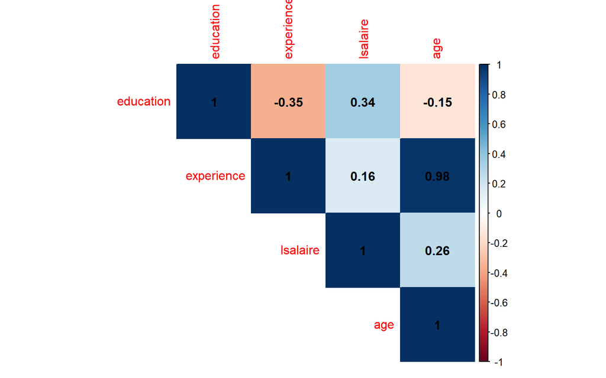

```r
par(mfrow=c(1,1))
corrplot(mcor,type="upper",addCoef.col = "black",method="color")
```

Dans la matrice de corrélation, on voit que les variables âge et expérience sont extremements corrélées, ainsi on peut d’ores et déjà dire que nous ne mettrons pas ces deux variables simultanement dans notre modèle pour éviter de rencontrer un problème de colinéarité.On peut également voir qu’il semble y avoir une corrélation positive entre le salaire et l’éducation ainsi que l’expérience.

## Question 9

On a vu d’après les questions précédentes qu’il semblait y avoir une corrélation positive entre entre le lsalaire et l’annee, nous allons donc integrer cette variable dans notre modèle.

Même si on voit une relation entre les variables explicatives sud et marie avec la variable expliqué lsalaire, d’un point de vue économique, nous ne pensons pas que le fait qu’une personne soit marié ou non puisse changer son niveau de salaire. De meme si la personne habite dans le sud ou non. Au contraire, les variables femmes,nonblanc education, expérience et syndicat semblent plus adéquates.

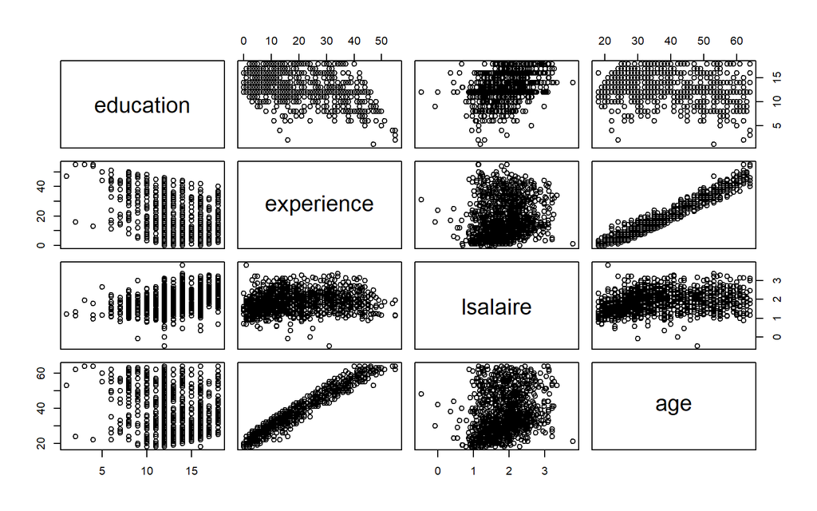

```r
plot(dataquant)
```

On voit à travers cette representation la très forte corrélation entre expérience et âge, on peut prudemment dire que se sont les “mêmes variables” et que donc on ne pourra pas utiliser les deux dans le même modèle comme vu à la question 8. Voici un premier modèle avec toutes les variables chosies grâce aux explications précèdentes :

lsalaire = B0 + B1education +B2experience + B3femme +B4nonblanc +B5syndicat + B6annee + erreur

```r
reg1<-lm(lsalaire~education+experience+nonblanc+femme+syndicat+annee,data=data)
summary(reg1)
```

```
##
## Call:
## lm(formula = lsalaire ~ education + experience + nonblanc + femme +
##     syndicat + annee, data = data)
##
## Residuals:
##      Min       1Q   Median       3Q      Max
## -2.39507 -0.27055  0.01555  0.27013  2.02686
##
## Coefficients:
##              Estimate Std. Error t value Pr(>|t|)
## (Intercept)  0.406165   0.075601   5.372 9.51e-08 ***
## education    0.087174   0.005027  17.340  < 2e-16 ***
## experience   0.012266   0.001061  11.564  < 2e-16 ***
## nonblanc1   -0.127712   0.040030  -3.190  0.00146 **
## femme1      -0.270091   0.026031 -10.376  < 2e-16 ***
## syndicat1    0.220295   0.030550   7.211 1.05e-12 ***
## annee85      0.399861   0.025747  15.531  < 2e-16 ***
## ---
## Signif. codes:  0 '***' 0.001 '**' 0.01 '*' 0.05 '.' 0.1 ' ' 1
##
## Residual standard error: 0.4167 on 1077 degrees of freedom
## Multiple R-squared:  0.414,  Adjusted R-squared:  0.4107
## F-statistic: 126.8 on 6 and 1077 DF,  p-value: < 2.2e-16
```

On obtient des coefficients logique d’un point de vue économique. De plus, les variables sont significatves grâce au test de student(pvalue<0.05). Toutefois nous allons voir si nous pouvons améliorer notre modèle.

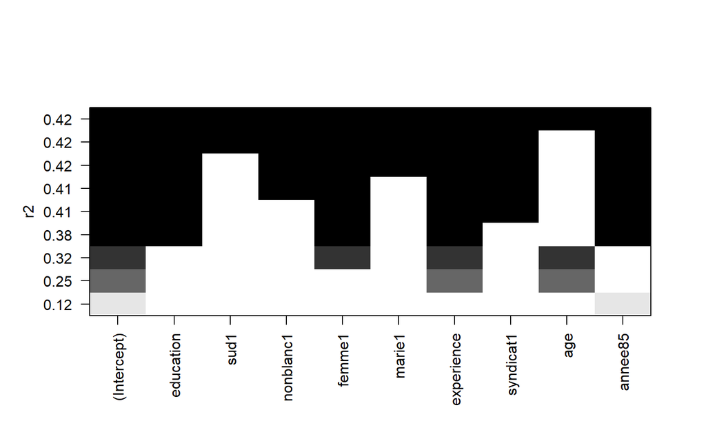

```r
recherche<-regsubsets(lsalaire~.,int=T,nbest=1,nvmax=9,method="exhaustive",really.big=T,data=data)
plot(recherche,scale="r2")
```

```r
summary(recherche)
```

```
## Subset selection object
## Call: regsubsets.formula(lsalaire ~ ., int = T, nbest = 1, nvmax = 9,
##     method = "exhaustive", really.big = T, data = data)
## 9 Variables  (and intercept)
##            Forced in Forced out
## education      FALSE      FALSE
## sud1           FALSE      FALSE
## nonblanc1      FALSE      FALSE
## femme1         FALSE      FALSE
## marie1         FALSE      FALSE
## experience     FALSE      FALSE
## syndicat1      FALSE      FALSE
## age            FALSE      FALSE
## annee85        FALSE      FALSE
## 1 subsets of each size up to 9
## Selection Algorithm: exhaustive
##          education sud1 nonblanc1 femme1 marie1 experience syndicat1 age
## 1  ( 1 ) " "       " "  " "       " "    " "    " "        " "       " "
## 2  ( 1 ) " "       " "  " "       " "    " "    "*"        " "       "*"
## 3  ( 1 ) " "       " "  " "       "*"    " "    "*"        " "       "*"
## 4  ( 1 ) "*"       " "  " "       "*"    " "    "*"        " "       " "
## 5  ( 1 ) "*"       " "  " "       "*"    " "    "*"        "*"       " "
## 6  ( 1 ) "*"       " "  "*"       "*"    " "    "*"        "*"       " "
## 7  ( 1 ) "*"       " "  "*"       "*"    "*"    "*"        "*"       " "
## 8  ( 1 ) "*"       "*"  "*"       "*"    "*"    "*"        "*"       " "
## 9  ( 1 ) "*"       "*"  "*"       "*"    "*"    "*"        "*"       "*"
##          annee85
## 1  ( 1 ) "*"
## 2  ( 1 ) " "
## 3  ( 1 ) " "
## 4  ( 1 ) "*"
## 5  ( 1 ) "*"
## 6  ( 1 ) "*"
## 7  ( 1 ) "*"
## 8  ( 1 ) "*"
## 9  ( 1 ) "*"
```

Grâce à ce graphique, on se rend compte que l’on peut obtenir un modèle avec un R2 quasiment similaire mais avec moins de variables explicatives, ce qui est intéressant pour la stabilité du modèle.On décide donc de retirer la variable nonblanc.(En plus du graphique précedent, on avait que la médiane semblait la même entre blanc et non blanc.) On peut prendre ce modèle :

lsalaire = B0 + B1experience + B2education + B3femme +B4syndicat +B5annee + erreur

```r
reg2<-lm(lsalaire~experience+education+femme+syndicat+annee,data=data)
summary(reg2)
```

```
##
## Call:
## lm(formula = lsalaire ~ experience + education + femme + syndicat +
##     annee, data = data)
##
## Residuals:
##     Min      1Q  Median      3Q     Max
## -2.5046 -0.2699  0.0138  0.2701  2.0409
##
## Coefficients:
##              Estimate Std. Error t value Pr(>|t|)
## (Intercept)  0.385487   0.075643   5.096 4.09e-07 ***
## experience   0.012182   0.001065  11.440  < 2e-16 ***
## education    0.088136   0.005040  17.489  < 2e-16 ***
## femme1      -0.272953   0.026126 -10.448  < 2e-16 ***
## syndicat1    0.213838   0.030613   6.985 4.97e-12 ***
## annee85      0.395958   0.025827  15.331  < 2e-16 ***
## ---
## Signif. codes:  0 '***' 0.001 '**' 0.01 '*' 0.05 '.' 0.1 ' ' 1
##
## Residual standard error: 0.4185 on 1078 degrees of freedom
## Multiple R-squared:  0.4084, Adjusted R-squared:  0.4057
## F-statistic: 148.9 on 5 and 1078 DF,  p-value: < 2.2e-16
```

Les coefficients sont toujours logique et les variables significatives grâce aux tests de student. Enfin, pour améliorer le modèle, nous avons penser que ce serait interressant avec ces variables de savoir si l’écart de salaire entre les femmes et les hommes pouvait augmenter avec l ’experience Voici un premier graphique pour voir si il peut y avoir un lien :

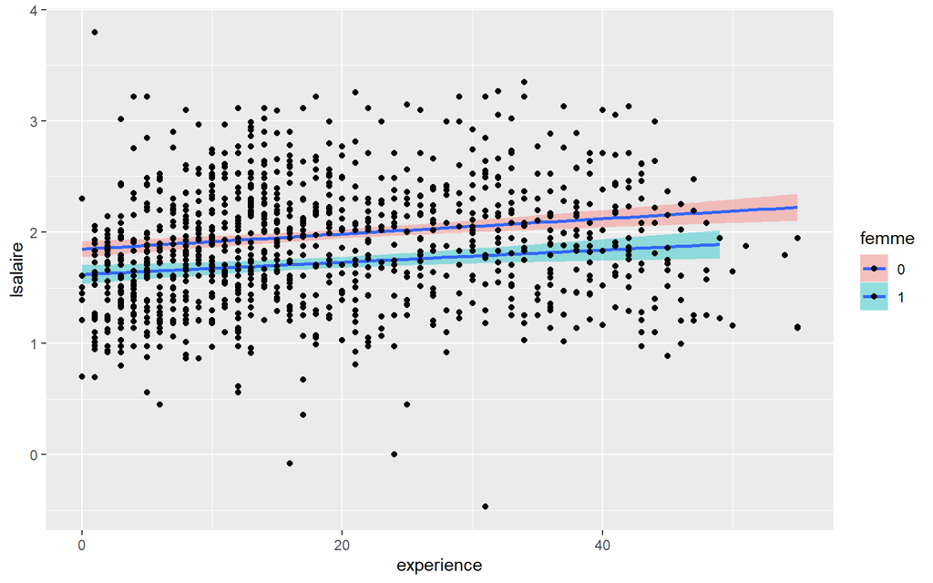

```r
ggplot(data, aes(x=experience, y=lsalaire, fill=femme))+
  geom_smooth(method="lm")+
  geom_point()
```

Il semble donc y avoir une différence entre les hommes et les femmes mais l’écart de salaire ne semble pas vraiment augmenter avec l’expérience. Si on ajoute cette interaction au modèle, on obtient :

lsalaire = B0 + B1education +B2experience + B3femme +B4experience*femme +B5syndicat + B6annee + erreur

Ce modèle sera le modèle retenu pour la suite.

```r
reg3<-lm(lsalaire~education+experience*femme+annee+syndicat,data=data)
summary(reg3)
```

```
##
## Call:
## lm(formula = lsalaire ~ education + experience * femme + annee +
##     syndicat, data = data)
##
## Residuals:
##      Min       1Q   Median       3Q      Max
## -2.53148 -0.25416  0.01068  0.27880  1.97522
##
## Coefficients:
##                    Estimate Std. Error t value Pr(>|t|)
## (Intercept)        0.324280   0.077942   4.161 3.43e-05 ***
## education          0.088987   0.005028  17.700  < 2e-16 ***
## experience         0.014749   0.001351  10.918  < 2e-16 ***
## femme1            -0.161388   0.044700  -3.610  0.00032 ***
## annee85            0.403029   0.025829  15.603  < 2e-16 ***
## syndicat1          0.212132   0.030499   6.955 6.09e-12 ***
## experience:femme1 -0.006201   0.002020  -3.070  0.00220 **
## ---
## Signif. codes:  0 '***' 0.001 '**' 0.01 '*' 0.05 '.' 0.1 ' ' 1
##
## Residual standard error: 0.4168 on 1077 degrees of freedom
## Multiple R-squared:  0.4136, Adjusted R-squared:  0.4103
## F-statistic: 126.6 on 6 and 1077 DF,  p-value: < 2.2e-16
```

```r
#model.tables(reg3) je sais pas encore quoi faire avec ca
```

Interprétation de la régression : Premièrement, toutes les variables sont significatives, pvalue <0.05 si on prend un risque à 5%. De plus, la significativité globale est maintenu car la statistique de Fisher est grande. On a un modèle Log-niveau pour toutes variables, calculons les effets marginaux :

```r
(exp(.088987)-1)*100 #education
```

```
## [1] 9.306645
```

```r
(exp(-0.161388)-1)*100 #femme
```

```
## [1] -14.90382
```

```r
(exp(.403029)-1)*100 #1985
```

```
## [1] 49.63503
```

```r
(exp(.212132)-1)*100 #Syndicat
```

```
## [1] 23.63111
```

Ainsi, une hausse d’une unité d’education qui peut s’apparenter à une année d’étude supplementaire entraîne une hausse de 9,30% de la moyenne géométrique du salaire, pour ce qui est de l’expérience, une année supplementaire n’entraîne une hausse que d’1% du salaire. L’effet d’une année d’étude est donc beaucoup plus important que l’effet d’une année d’expérience. Le fait d’être une femme a un effet non négligeable sur le salaire puis cela entraine une baisse de 14,9% du salaire par rapport aux hommes. On peut aussi remarquer,que le fait d’être en 1985 entraîne une moyenne géométrique des salaires 49% plus élevé. Le fait d’être syndicat permet quand à lui de majoré la moyene géométrique du salaire d’environ 23%.

Pour l’interaction entre femme et experience, si on a une femme, on aura lsalaire = B0 + B1education +B2experience + B3femme +B4experience*femme +B5syndicat + B6annee + erreur et l’effet marginal se calculera avec B2+B4 Si on a un homme, on aura:

lsalaire = B0 + B1education +B2experience+B5syndicat + B6annee, donc l’effet marginal se calculera seulement avec B2

```r
(exp(.014749)-1)*100#experience avec B2 donc pour un homme
```

```
## [1] 1.48583
```

```r
(exp(.014749-0.006201)-1)*100
```

```
## [1] 0.8584638
```

On remarque donc que le fait d’être une femme à un effet moins important sur le salaire si on gagne une année d’expérience que si on est un homme. Il semble donc que l’écart de salaire s’accroit avec l’expérience entre les hommes et les femmes.

## Question 10

```r
#Règle de KLEIN
cor(dataquant)^2 > summary(reg3)$r.squared
```

```
##            education experience lsalaire   age
## education       TRUE      FALSE    FALSE FALSE
## experience     FALSE       TRUE    FALSE  TRUE
## lsalaire       FALSE      FALSE     TRUE FALSE
## age            FALSE       TRUE    FALSE  TRUE
```

```r
#Il semble y avoir de la colinéarité seulement entre experience et age ce qui avait deja été determiné plus tot.
vif(reg3)
```

```
##        education       experience            femme            annee
##         1.153322         1.887388         3.030539         1.040381
##         syndicat experience:femme
##         1.069152         3.665002
```

```r
#On n'écarte aucunes variables explicatives.
#Il ne semble donc pas y avoir de colinearite entre les variables explicatives dans le modele
```

## Question 11

```r
data$salaireadjust<-ifelse(data$annee=="78",data$lsalaire,data$lsalaire-log(1.65))
#On ajoute une variable qui ajuste le lsalaire avec la déflation pour 1985.

regadjust<-lm(salaireadjust~education+experience*femme+annee+syndicat,data=data)
summary(regadjust)
```

```
##
## Call:
## lm(formula = salaireadjust ~ education + experience * femme +
##     annee + syndicat, data = data)
##
## Residuals:
##      Min       1Q   Median       3Q      Max
## -2.53148 -0.25416  0.01068  0.27880  1.97522
##
## Coefficients:
##                    Estimate Std. Error t value Pr(>|t|)
## (Intercept)        0.324280   0.077942   4.161 3.43e-05 ***
## education          0.088987   0.005028  17.700  < 2e-16 ***
## experience         0.014749   0.001351  10.918  < 2e-16 ***
## femme1            -0.161388   0.044700  -3.610 0.000320 ***
## annee85           -0.097747   0.025829  -3.784 0.000163 ***
## syndicat1          0.212132   0.030499   6.955 6.09e-12 ***
## experience:femme1 -0.006201   0.002020  -3.070 0.002196 **
## ---
## Signif. codes:  0 '***' 0.001 '**' 0.01 '*' 0.05 '.' 0.1 ' ' 1
##
## Residual standard error: 0.4168 on 1077 degrees of freedom
## Multiple R-squared:  0.3421, Adjusted R-squared:  0.3384
## F-statistic: 93.33 on 6 and 1077 DF,  p-value: < 2.2e-16
```

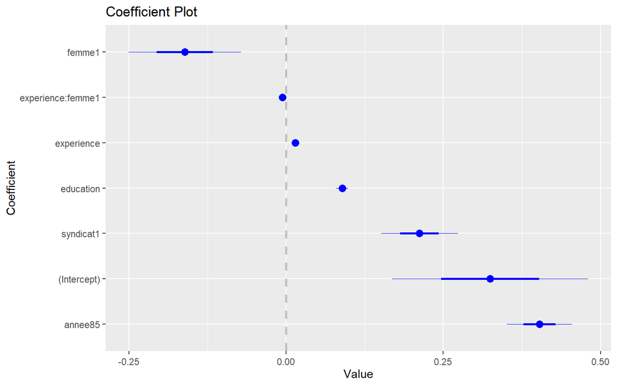

```r
#On remarque que le R2 baisse ainsi que la valeur de la statistique de Fisher, mais les variables restent significatives.
coefplot(reg3, decreasing = TRUE, sort = "magnitude")
```

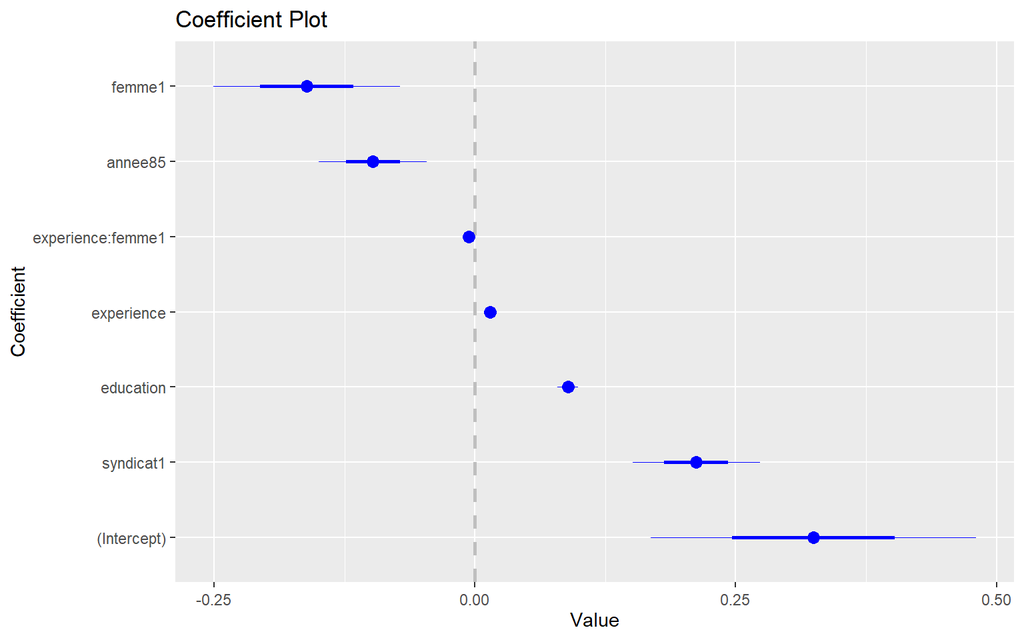

```r
coefplot(regadjust, decreasing = TRUE, sort = "magnitude")
```

On remarque que seul le coefficient pour la variable année change, dans le modèle avec déflation, passant de 0,40 à -0.09

```r
#=> interpretation log niveau avec annee, donc augmente de 49,6% la moyenne géometrique de lsalaire
(exp(0.403029)-1)*100
```

```
## [1] 49.63503
```

```r
#=> interpretation log niveau avec annee, donc augmente de -9,3% la moyenne géometrique de salaireadjust
(exp(-0.097747)-1)*100
```

```
## [1] -9.312169
```

## Question 12

On peut mettre en place un test de Chow pour comparer “deux modèles” dans un même modèle

```r
summary(reg78<-lm(lsalaire~education+experience*femme+syndicat,data=subset(data, data$annee=="78")))
```

```
##
## Call:
## lm(formula = lsalaire ~ education + experience * femme + syndicat,
##     data = subset(data, data$annee == "78"))
##
## Residuals:
##      Min       1Q   Median       3Q      Max
## -2.54064 -0.23372  0.00582  0.21718  1.29202
##
## Coefficients:
##                    Estimate Std. Error t value Pr(>|t|)
## (Intercept)        0.462229   0.098331   4.701 3.29e-06 ***
## education          0.080977   0.006414  12.624  < 2e-16 ***
## experience         0.013632   0.001637   8.326 6.79e-16 ***
## femme1            -0.245273   0.058582  -4.187 3.30e-05 ***
## syndicat1          0.214110   0.036933   5.797 1.14e-08 ***
## experience:femme1 -0.003918   0.002653  -1.477     0.14
## ---
## Signif. codes:  0 '***' 0.001 '**' 0.01 '*' 0.05 '.' 0.1 ' ' 1
##
## Residual standard error: 0.3887 on 544 degrees of freedom
## Multiple R-squared:  0.3768, Adjusted R-squared:  0.3711
## F-statistic:  65.8 on 5 and 544 DF,  p-value: < 2.2e-16
```

```r
summary(reg85<-lm(lsalaire~education+experience*femme+syndicat,data=subset(data, data$annee=="85")))
```

```
##
## Call:
## lm(formula = lsalaire ~ education + experience * femme + syndicat,
##     data = subset(data, data$annee == "85"))
##
## Residuals:
##      Min       1Q   Median       3Q      Max
## -2.12960 -0.29565  0.00867  0.31047  1.92320
##
## Coefficients:
##                    Estimate Std. Error t value Pr(>|t|)
## (Intercept)        0.574757   0.121688   4.723 2.98e-06 ***
## education          0.097966   0.007855  12.472  < 2e-16 ***
## experience         0.015802   0.002267   6.971 9.45e-12 ***
## femme1            -0.081512   0.067970  -1.199  0.23097
## syndicat1          0.201947   0.051124   3.950 8.87e-05 ***
## experience:femme1 -0.008276   0.003121  -2.652  0.00824 **
## ---
## Signif. codes:  0 '***' 0.001 '**' 0.01 '*' 0.05 '.' 0.1 ' ' 1
##
## Residual standard error: 0.4432 on 528 degrees of freedom
## Multiple R-squared:  0.3014, Adjusted R-squared:  0.2948
## F-statistic: 45.56 on 5 and 528 DF,  p-value: < 2.2e-16
```

```r
summary(regtot<-lm(lsalaire~education+experience*femme+syndicat,data=data))
```

```
##
## Call:
## lm(formula = lsalaire ~ education + experience * femme + syndicat,
##     data = data)
##
## Residuals:
##      Min       1Q   Median       3Q      Max
## -2.65789 -0.29172 -0.01865  0.31110  2.17557
##
## Coefficients:
##                    Estimate Std. Error t value Pr(>|t|)
## (Intercept)        0.473109   0.085615   5.526 4.11e-08 ***
## education          0.094541   0.005550  17.033  < 2e-16 ***
## experience         0.013844   0.001494   9.268  < 2e-16 ***
## femme1            -0.187204   0.049438  -3.787 0.000161 ***
## syndicat1          0.151127   0.033476   4.514 7.05e-06 ***
## experience:femme1 -0.003390   0.002227  -1.523 0.128154
## ---
## Signif. codes:  0 '***' 0.001 '**' 0.01 '*' 0.05 '.' 0.1 ' ' 1
##
## Residual standard error: 0.4613 on 1078 degrees of freedom
## Multiple R-squared:  0.281,  Adjusted R-squared:  0.2777
## F-statistic: 84.26 on 5 and 1078 DF,  p-value: < 2.2e-16
```

```r
SCR78=sum(reg78$residuals^2)
SCR85=sum(reg85$residuals^2)
SCRtot=sum(regtot$residuals^2)
(CHOWF=((SCRtot-(SCR78+SCR85))/(SCR78+SCR85))*(1084-12)/(6))
```

```
## [1] 41.83472
```

```r
qf(.95, df1=6, df2=1074)
```

```
## [1] 2.107008
```

```r
pf(CHOWF,df1=6, df2=1074,lower.tail = FALSE)
```

```
## [1] 5.509342e-46
```

On a tous d’abord écrit notre modèle pour l’année 78 puis notre modèle pour l’année 85. Ensuite, nous avons calculé la somme des carrés des résidus pour chaque modèles. Enfin, on a calculé la statistique observé et on la compare avec la statistique de la table. On voit que la statistique observée est plus élevée que la valeur de la table. De plus, la p value est très faible ce qui signifie que l’on peut rejetter l’hypothèse H0 que tous les coefficients sont égaux, la relation estimée a donc changée avec les années.

## Question 13

```r
reg13<-lm(data$lsalaire~annee*femme)
summary(reg13)
```

```
##
## Call:
## lm(formula = data$lsalaire ~ annee * femme)
##
## Residuals:
##      Min       1Q   Median       3Q      Max
## -2.28292 -0.33364  0.00813  0.32718  1.86147
##
## Coefficients:
##              Estimate Std. Error t value Pr(>|t|)
## (Intercept) -2.113376   0.452595  -4.669  3.4e-06 ***
## annee        0.050337   0.005569   9.039  < 2e-16 ***
## femme       -1.679358   0.703836  -2.386   0.0172 *
## annee:femme  0.017037   0.008623   1.976   0.0484 *
## ---
## Signif. codes:  0 '***' 0.001 '**' 0.01 '*' 0.05 '.' 0.1 ' ' 1
##
## Residual standard error: 0.4882 on 1080 degrees of freedom
## Multiple R-squared:  0.1934, Adjusted R-squared:  0.1911
## F-statistic:  86.3 on 3 and 1080 DF,  p-value: < 2.2e-16
```

Le modèle s’écrit : lsalaire = B0 + B1femme + B2annee + B3annee*femme + erreur Tout d’abord, il semble que l’interaction entre femme et année soit significative. Interpretons les effets marginaux pour savoir si l’ecart de salaire à augmenter ou pas

Si on est une femme en 78 :

lsalaire = B0 +B2femme

```r
1+1
```

```
## [1] 2
```

```r
(exp(-1.679358)-1)*100
```

```
## [1] -81.35063
```

Si on est une femme en 85:

lsalaire = B0+ B1année +B2femme +B3annee*femme

```r
(exp(-1.679358+0.017037)-1)*100
```

```
## [1] -81.03018
```

Si on est un homme en 78:

lsalaire = B0

Si on est un homme en 85:

lsalaire = B0 + B1annee

```r
(exp(0.050337)-1)*100
```

```
## [1] 5.162543
```

```r
(exp(0.017037)-1)*100
```

```
## [1] 1.718296
```

L’effet marginal de l’interaction est seulement de 1.7% Le coefficient correspondant à l’intéraction annee:femme est postif, cela veut dire que le coefficient année va augmenter de 0.017037 si on est une femme, et donc dire que l’écart de salaire va diminuer mais très peu. Faisons un test de chow :

```r
library(strucchange)
sctest(lsalaire~femme*annee,data=data,type="Chow")
```

```
##
##  Chow test
##
## data:  lsalaire ~ femme * annee
## F = 3.6101, p-value = 0.006236
```

La pvalue(<0.05) de ce test montre que l’on peut rejetter l’hypothèse H0 donc il est possible que le gender gap est évolué.

```r
femme78<-c(mean(lsalaire[femme=="1"& annee=="78"]))
femme85<-c(mean(lsalaire[femme=="1"& annee=="85"]))
homme78<-c(mean(lsalaire[femme=="0"& annee=="78"]))
homme85<-c(mean(lsalaire[femme=="0"& annee=="85"]))
ecart78<-c(homme78-femme78)
ecart85<-c(homme85-femme85)
matrice<-matrix(c(femme78,femme85,homme78,homme85,ecart78,ecart85),nrow=6,ncol=1)
rownames(matrice)<-c("femme 78","femme 85","homme 78", "homme 85","Ecart 78","Ecart85")
colnames(matrice)<-c("Moyenne/Ecart")
matrice%>%kable(caption="Ecart de moyenne du salaire entre homme et femme par année")
```

Ecart de moyenne du salaire entre homme et femme par année

|  | Moyenne/Ecart |
| --- | --- |
| femme 78 | 1.4624121 |
| femme 85 | 1.9340278 |
| homme 78 | 1.8129207 |
| homme 85 | 2.1652806 |
| Ecart 78 | 0.3505086 |
| Ecart85 | 0.2312529 |

On remarque que l’écart des moyennes semblent avoir baissé de plus de 0.1 ce qui n’est pas négligeable lorsque l’on affecte le logarithme à la variable salaire.

## Question 14

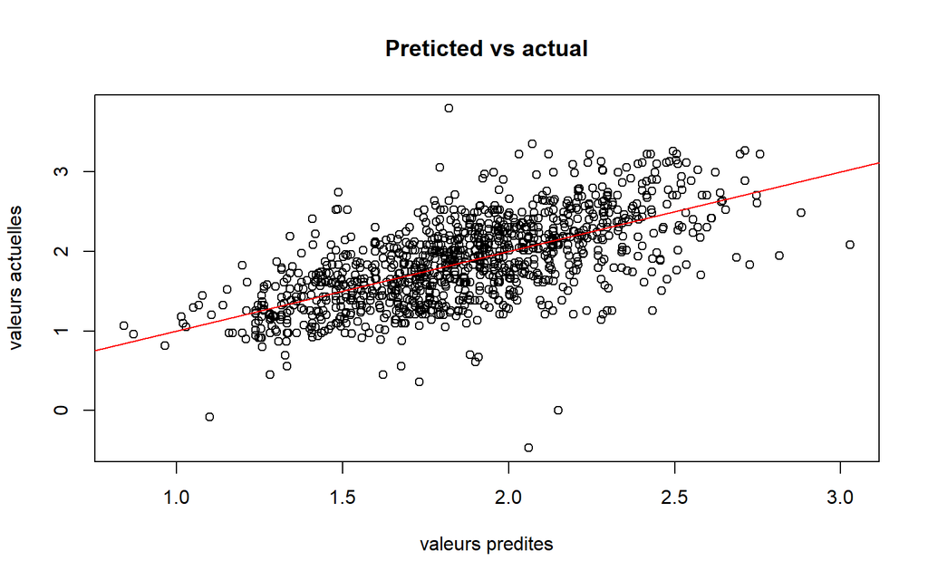

```r
fitted=predict(reg3, data)
plot(lsalaire~fitted,main="Preticted vs actual",xlab="valeurs predites",ylab="valeurs actuelles")
abline(a=0, b=1, col="red")
```

Le modèle est plutôt correct

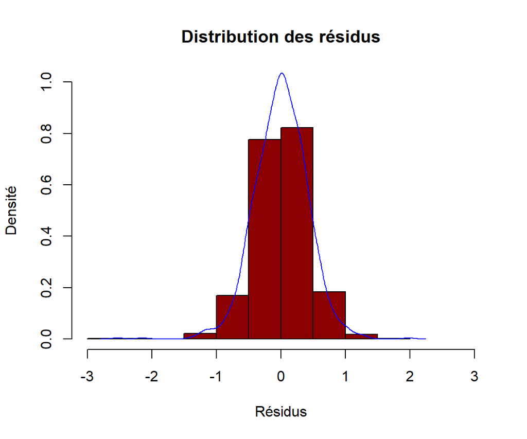

```r
par(mfrow=c(1,1))
hist(reg3$residuals, freq=FALSE,col="darkred",main="Distribution des résidus",xlab="Résidus",ylab="Densité",xlim=c(-3,3),ylim=c(0,1))
lines(density(reg3$residuals),col="blue")
```

La distribution des résidus suit la distribution d’une loi normale, ils sont biens centrés sur 0

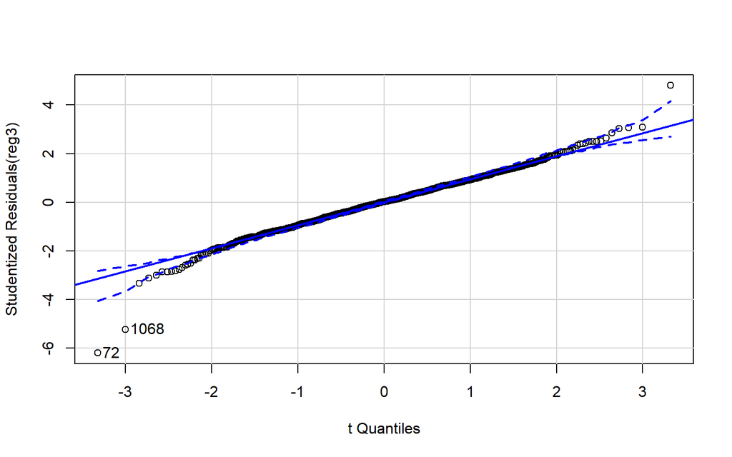

```
## [1]   72 1068
```

```r
qqPlot(reg3, id.n=2)
```

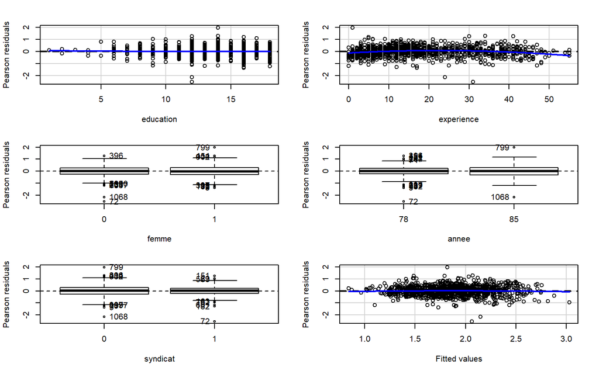

```
##            Test stat Pr(>|Test stat|)
## education     0.5142           0.6072
## experience   -5.3736         9.46e-08 ***
## femme
## annee
## syndicat
## Tukey test   -0.7825           0.4339
## ---
## Signif. codes:  0 '***' 0.001 '**' 0.01 '*' 0.05 '.' 0.1 ' ' 1
```

```r
residualPlots(reg3)
```

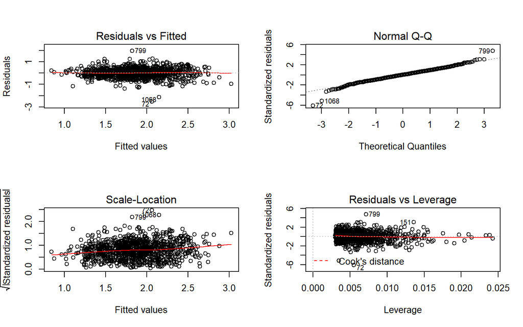

```r
par(mfrow=c(2,2))
plot(reg3)
```

Graphiquement, les résidus semblent plutôt constant, il n’y a pas d’explosions de la valeurs des résidus, toutefois certaines observation ont des résidus standardisés assez élevés. Vérifions par un test qu’il n’y a pas d’hétéroscédasticité.

```r
bptest(reg3)
```

```
##
##  studentized Breusch-Pagan test
##
## data:  reg3
## BP = 16.439, df = 6, p-value = 0.01158
```

La p_value est inférieur au risque de première espèce, on rejette l’hypothèse H0 donc il semble y avoir de l’hétéroscédasticité.

```r
library(sandwich)
reg3 %>% vcovHC %>% diag() %>% sqrt()
```

```
##       (Intercept)         education        experience            femme1
##       0.077606282       0.005106403       0.001444927       0.043391532
##           annee85         syndicat1 experience:femme1
##       0.025802753       0.029876728       0.002074776
```

On obtient ici les ecarts types robustes après avoir corrigé la matrice des variances-covariances. On remarque que les écarts types sont extremement proches des écarts types standardisés, les variables restent donc toutes significatives. Donc même avec la correction de l’hétéroscédasticité, les variables sont significatives. Le modèle ne semble pas présenter de problèmes.